# Part II - Effects of Reason delay on Their Departure delay

## Dataset Overview

This document explores a dataset containing flights and attributes for approximately 7,500,000 flights and other table are airports (3,300 rows), plane-data (5,000 rows). The attributes included flights minutes, scheduled flight minutes, delay minutes, reason delay minutes, origin city, origin state, manufacture and time.

## Distribution of Departure Delay using the transformation

Observations: The Flights Minutes variable took on a large range of values, so I looked at the data using a log transform. Under the transformation, the data looked unimodal, with one peak between 250 𝑎𝑛𝑑 300

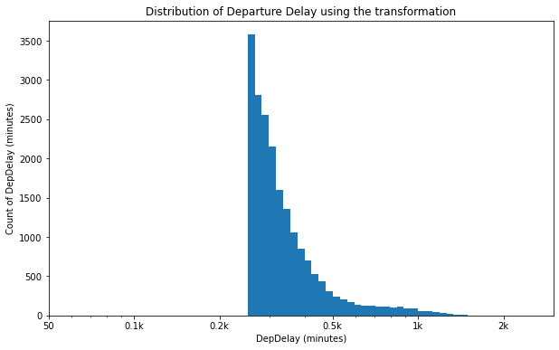

## Distribution flights par month in 2007

Observations:

Number of flights are hight in begining of year and in the end of year

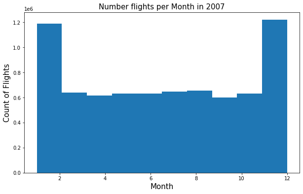

## Correlation of feature

Observations:

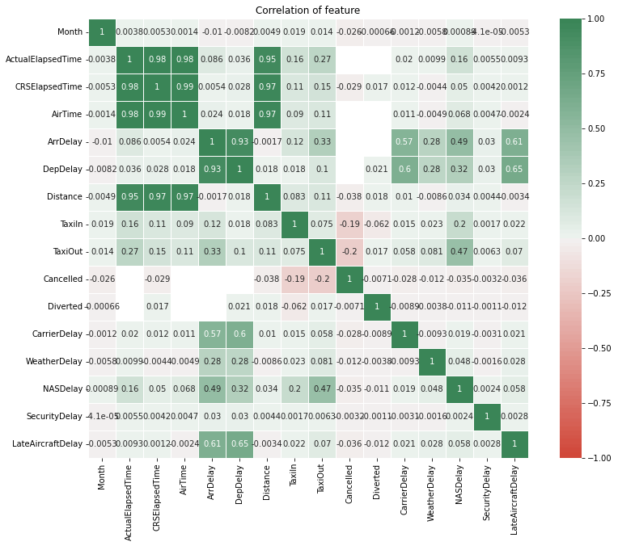

## Arrival Delay Minutes par month in 2007

Observations:

Departure Delay minutes and Arrival Delay minutes have the most late in Juin

Departure Delay minutes and Arrival Delay minutes have the least late in September

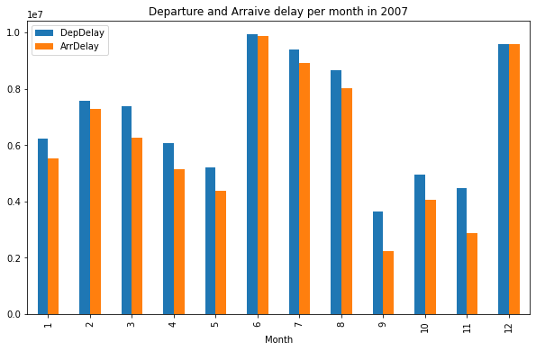

## Reason Delay Minutes par month in 2007

Observations:

In for reason delay: LateAircraftDelay, NASDelay, WeatherDelay, CarrierDelay

- DepDelay have link with reason delay
- LateAircraftDelay is the most common cause
- WeatherDelay is the least common cause
- NASDelay and CarrierDelay are nearly equal reason

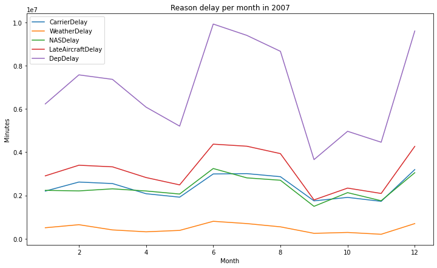

## Flight Delay Minutes par manufacture in 2007

Observations:

In all manufacture have total flights minutes in 2007:

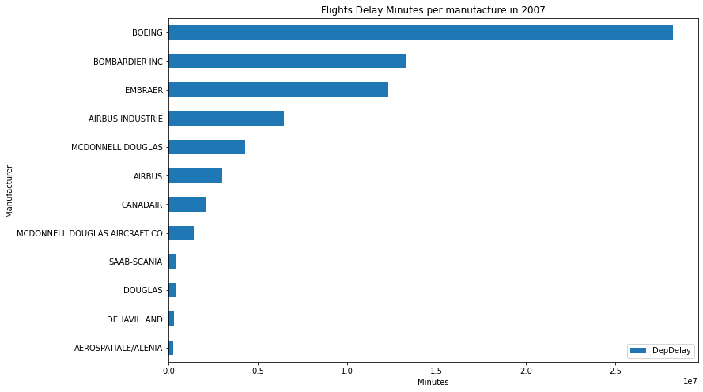

## Arrival Departure Delay Minutes per manufacture in 2007

Observations:

In all manufacture have departure delay and arrival delay in 2007:

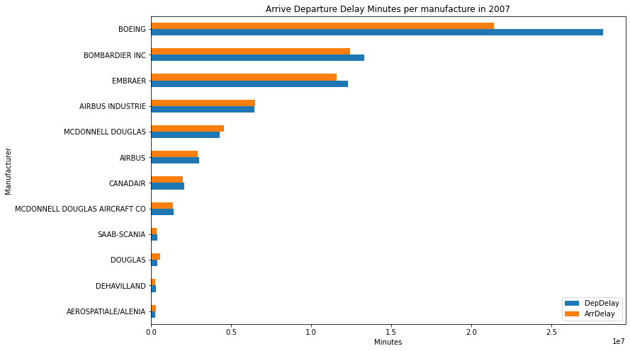

## Distribution DepDelay and ArrDelay per City Origin

Observations:

In all City Origin have ArrDelay and DepDelay in 2007:

- Chicago have the most total flights delay minutes in 2007, then Atlanta

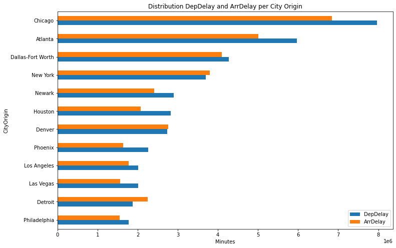

## Distribution Reasion deday (CarrierDelay, WeatherDelay, NASDelay , SecurityDelay, LateAircraftDelay) and DepDelay per State Origin

Observations:

In all rgion have CarrierDelay, WeatherDelay, NASDelay, SecurityDelay and LateAircraftDelay in 2007:

- SecurityDelay is the least common cause
- LateAircraftDelay is the most common cause
- Althought CA have the mót flight in 2007, but TX is the most WeatherDelay,NASDelay and LateAircraftDelay

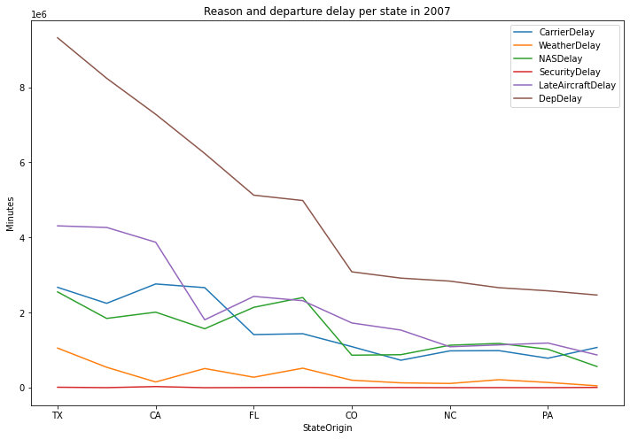

### Discuss the distribution(s) of your variable(s) of interest. Were there any unusual points? Did you need to perform any transformations?

The Flights Minutes variable took on a large range of values, so I looked at the data using a log transform. Under the transformation, the data looked unimodal, with one peak between 250 𝑎𝑛𝑑 300

### Of the features you investigated, were there any unusual distributions? Did you perform any operations on the data to tidy, adjust, or change the form of the data? If so, why did you do this?

The initial plot of the 'Year', 'Month', 'DayofMonth' features show good points. There are not any unusual distributions

### Talk about some of the relationships you observed in this part of the investigation. Were there features that strengthened each other in terms of looking at your feature(s) of interest?

In this point, LateAircraftDelay have the closest correlection with departure delay

## Conclusions

- LateAircraftDelay is the main reason of departure delay minutes.
- Boeing have the most total departure delay minutes
- TX state have the most total departure delay minutes
- Chicago city have the most total departure delay minutes